# SLU Markfuktighetskarta

William Lidberg

2020 J06 18

Load packages

```r
library(caret)
library(raster)
library(rgdal)
library(doParallel)
library(xgboost)
library(ggplot2)
library(cluster)
```

Load training data and convert appropriate features to factor

```r
OriginalDataNumeric<-read.table("X:/XGBoostArticle/TrainingData/XGBoostTrainingData.txt",  stringsAsFactors=FALSE, header = TRUE, dec = ",")
OriginalDataNumeric<-na.omit(OriginalDataNumeric)

#Set moisture label to factor
OriginalData<-OriginalDataNumeric
colsF <- c("Markfuktig","soil","wetlands")
OriginalData[colsF]<- lapply(OriginalData[colsF], factor)
str(OriginalData)
```

```
## 'data.frame':    19647 obs. of  25 variables:
##  $ dtw1      : num  0.259 0.309 0 0.02 0.115 ...
##  $ dtw5      : num  0.507 1.098 0.974 0.02 1.763 ...
##  $ dtw30     : num  0.507 6.4 6.098 0.02 1.763 ...
##  $ stdv5     : num  0.0935 0.0761 0.0337 0.0665 0.0581 ...
##  $ Winter    : num  70.7 106.3 106.3 98.5 91 ...
##  $ Summer    : num  13.4 17.2 17.2 20.2 20.3 ...
##  $ Autum     : num  12.8 25.9 25.9 21.2 22.9 ...
##  $ dtw05     : num  0.2732 0.2821 0.0248 0.0168 0.1327 ...
##  $ wetlands  : Factor w/ 2 levels "0","1": 1 1 1 1 1 1 1 2 2 1 ...
##  $ di2       : int  713 531 1573 2630 399 354 11 1683 94 63 ...
##  $ soil      : Factor w/ 7 levels "50","75","86",..: 1 1 1 1 1 2 5 2 5 3 ...
##  $ coordy    : int  6138147 6143736 6143715 6143456 6143777 6148381 6148380 6148104 6148401 6153358 ...
##  $ coordx    : int  377496 427687 427401 427691 432399 397647 397364 397644 422644 397314 ...
##  $ TWI24m    : num  7.78 6.5 9.82 10.45 9.26 ...
##  $ TWI48m    : num  9.51 9.31 10.85 10.1 9.73 ...
##  $ Markfuktig: Factor w/ 5 levels "1","2","3","4",..: 3 2 2 2 2 3 2 3 2 2 ...
##  $ CVA       : num  0.881 0.411 0.547 0.506 0.789 ...
##  $ DFME      : num  -0.42607 0.95581 0.00657 -0.52507 -1.56339 ...
##  $ Rugged    : num  0.0472 0.0609 0.0379 0.0357 0.0553 ...
##  $ SDFS      : num  0.642 0.926 0.705 0.421 0.594 ...
##  $ SoilDepth : num  10.7 15.6 15.6 19.5 23 ...
##  $ TWI10m    : int  7 7 8 11 13 8 6 8 8 9 ...
##  $ dtw2      : num  0.512 0.284 0 0 1.098 ...
##  $ Elevation : num  0.801 3.966 3.904 2.628 3.409 ...
##  $ Slope     : num  1.483 1.791 0.713 1.053 0.855 ...
```

Reclassify data into three classes instead of five

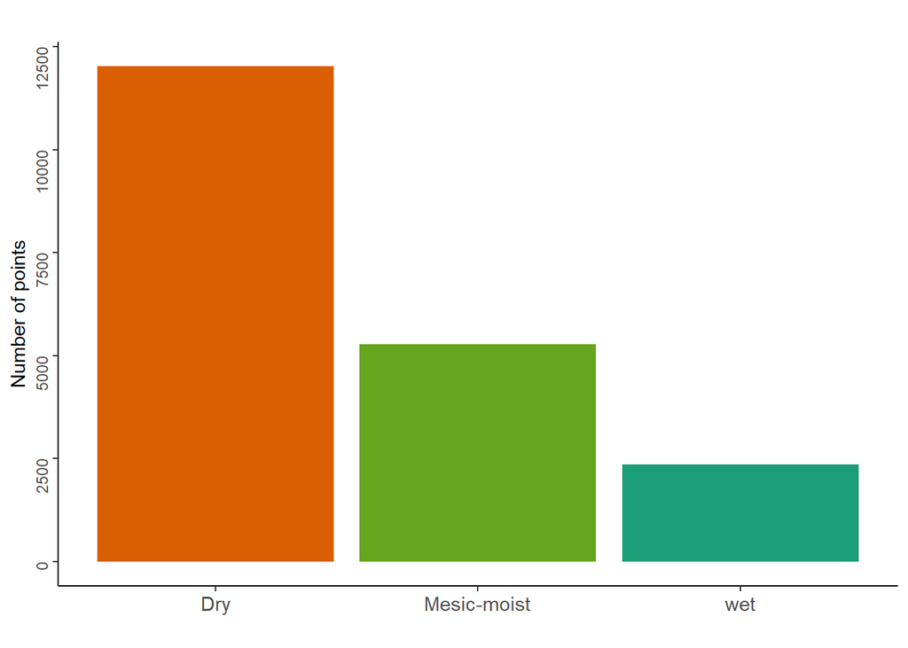

```r
library(RColorBrewer)
ternaryMoisture<- ifelse(OriginalDataNumeric$Markfuktig<3,1,ifelse(OriginalDataNumeric$Markfuktig>3,3,2))
ternarydataset<-cbind(OriginalData,ternaryMoisture)
ternarydataset$Markfuktig<-NULL
colF <- c("ternaryMoisture")
ternarydataset[colF]<- lapply(ternarydataset[colF], factor)

#plot distribution

cols <- c("1"="#D95F02","2"="#66A61E","3"="#1B9E77")

three<-ggplot(data=ternarydataset, aes(x=ternaryMoisture)) +
  geom_bar(aes(fill = ternaryMoisture)) +
  labs(title = "", x = "", y = "Number of points")

three + theme_bw() + theme(legend.position = "none") + theme(axis.text = element_text(angle = 90),panel.border = element_blank(), panel.grid.major = element_blank(), panel.grid.minor = element_blank(), axis.line = element_line(colour = "black")) + scale_fill_manual(values = cols) + scale_x_discrete(labels=c("Dry", "Mesic-moist", "wet")) + theme(axis.text.x = element_text(angle = 0, size=11, hjust = 0.5))
```

Split data into training data 80 % and test data 20 %.

```r
set.seed(42)
#split three classed dataset
ternaryTrainingDataIndex<- createDataPartition(ternarydataset$ternaryMoisture, p=0.8, list = FALSE)
ternarytrainingData <- ternarydataset[ternaryTrainingDataIndex,]
ternarytestData <- ternarydataset[-ternaryTrainingDataIndex,]
```

Start by tuning max depth and learning rate (eta) while leaving everything else as default. Learning rate controls how much information from a new tree will be used in the Boosting. If it is close to zero we will use only a small piece of information from each new tree. If we set eta to 1 we will use all information from the new tree. Big values of eta result in a faster convergence and more over-fitting problems. Small values may need to many trees to converge.

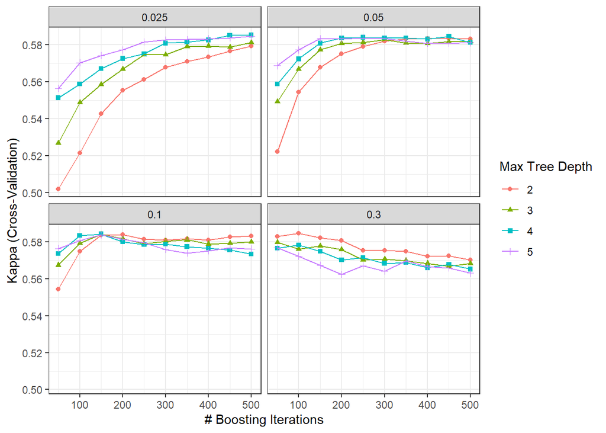

```r
set.seed(42)

#Tune grid
XGBoostgrid1 = expand.grid(
  nrounds = seq(from = 50, to = 500, by = 50),
  max_depth = c(2,3,4,5),
  eta = c(0.025, 0.05, 0.1, 0.3),
  gamma = c(0),
  colsample_bytree = c(1),
  min_child_weight = c(1),
  rate_drop = c(0),
  skip_drop = c(0),
  subsample = c(1)
)

#Five fold cross validation will be used for tuning
tune_control <- caret::trainControl(method = "cv", number = 10, verboseIter = FALSE, allowParallel = TRUE)

xgbDARTtuningmodel3classedseed <- caret::train(ternaryMoisture~., data = ternarytrainingData, trControl = tune_control, tuneGrid = XGBoostgrid1, method = "xgbDART",verbose = TRUE, metric="Kappa")


#tuneplot(xgbDARTtuningmodel3classedseed)
ggplot(xgbDARTtuningmodel3classedseed) + theme_bw()
```

```r
print(xgbDARTtuningmodel3classedseed$bestTune)
```

```
##    nrounds max_depth   eta gamma subsample colsample_bytree rate_drop skip_drop
## 90     500         4 0.025     0         1                1         0         0
##    min_child_weight
## 90                1
```

We will keep testing some values for max depth around the optimal while we tune rate drop and skip drop. Dropout value is a fraction of previous trees to drop during the dropout. If a dropout is skipped, new trees are added in the same manner as gbtree. If all trees are dropped the model is no different than random forest.

```r
set.seed(42)
XGBoostgrid2 <- expand.grid(
  nrounds = seq(from = 50, to = 500, by = 50),
  eta = xgbDARTtuningmodel3classedseed$bestTune$eta,
  max_depth = c(xgbDARTtuningmodel3classedseed$bestTune$max_depth - 1, xgbDARTtuningmodel3classedseed$bestTune$max_depth, xgbDARTtuningmodel3classedseed$bestTune$max_depth + 1),
  gamma = 0,
  colsample_bytree = 1,
  min_child_weight = c(1),
  rate_drop = c(0,0.25,0.5,0.75,1),
  skip_drop = c(0,0.25,0.5,0.75,1),
  subsample = c(1)
)

xgbDARTtuningmodel3classedseed2 <- caret::train(ternaryMoisture~., data = ternarytrainingData, trControl = tune_control, tuneGrid = XGBoostgrid2, method = "xgbDART",verbose = TRUE, metric="Kappa")
xgbDARTtuningmodel3classedseed2$bestTune
```

```
##     nrounds max_depth   eta gamma subsample colsample_bytree rate_drop
## 260     500         4 0.025     0         1                1         0
##     skip_drop min_child_weight
## 260         0                1
```

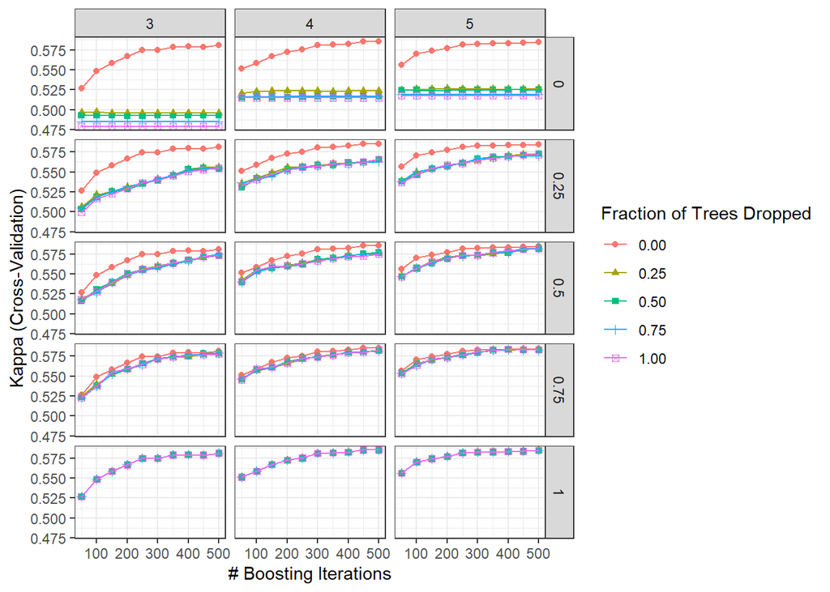

```r
#tuneplot(xgbDARTtuningmodel3classedseed2)
ggplot(xgbDARTtuningmodel3classedseed2) + theme_bw()
```

Tune Column and Row Sampling. Subsampling occurs once for every tree constructed.

```r
set.seed(42)
XGBoostgrid3 <- expand.grid(
  nrounds = seq(from = 50, to = 500, by = 50),
  eta = xgbDARTtuningmodel3classedseed$bestTune$eta,
  max_depth = xgbDARTtuningmodel3classedseed2$bestTune$max_depth,
  gamma = 0,
  colsample_bytree = c(0.5, 0.75, 1.0),
  min_child_weight = c(1),
  rate_drop = xgbDARTtuningmodel3classedseed2$bestTune$rate_drop,
  skip_drop = xgbDARTtuningmodel3classedseed2$bestTune$skip_drop,
  subsample = c(0.5, 0.75, 1.0)
)

xgbDARTtuningmodel3classedseed3 <- caret::train(ternaryMoisture~., data = ternarytrainingData, trControl = tune_control, tuneGrid = XGBoostgrid3, method = "xgbDART",verbose = TRUE, metric="Kappa")

xgbDARTtuningmodel3classedseed3$bestTune
```

```
##    nrounds max_depth   eta gamma subsample colsample_bytree rate_drop skip_drop
## 50     500         4 0.025     0      0.75             0.75         0         0
##    min_child_weight
## 50                1
```

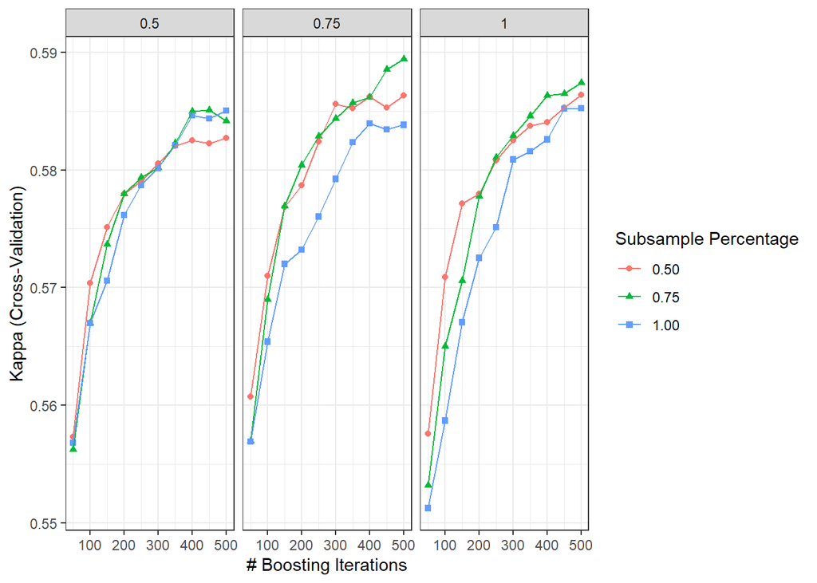

```r
#tuneplot(xgbDARTtuningmodel3classedseed3)
ggplot(xgbDARTtuningmodel3classedseed3) + theme_bw()
```

min_child_weigth Controls the minimum number of observations (instances) in a terminal node. The minimum value for this parameter is 1, which allows the tree to have terminal nodes with only one observation. If we use bigger values we limit a possible perfect fit on some observations.

```r
set.seed(42)

XGBoostgrid4 <- expand.grid(
  nrounds = seq(from = 50, to = 500, by = 50),
  eta = xgbDARTtuningmodel3classedseed$bestTune$eta,
  max_depth = xgbDARTtuningmodel3classedseed2$bestTune$max_depth,
  gamma = 0,
  colsample_bytree = xgbDARTtuningmodel3classedseed3$bestTune$colsample_bytree,
  min_child_weight = c(1, 2, 3),
  rate_drop = xgbDARTtuningmodel3classedseed2$bestTune$rate_drop,
  skip_drop = xgbDARTtuningmodel3classedseed2$bestTune$skip_drop,
  subsample = xgbDARTtuningmodel3classedseed3$bestTune$subsample)

xgbDARTtuningmodel3classedseed4 <- caret::train(ternaryMoisture~., data = ternarytrainingData, trControl = tune_control, tuneGrid = XGBoostgrid4, method = "xgbDART",verbose = TRUE, metric="Kappa")
xgbDARTtuningmodel3classedseed4$bestTune
```

```
##    nrounds max_depth   eta gamma subsample colsample_bytree rate_drop skip_drop
## 28     400         4 0.025     0      0.75             0.75         0         0
##    min_child_weight
## 28                3
```

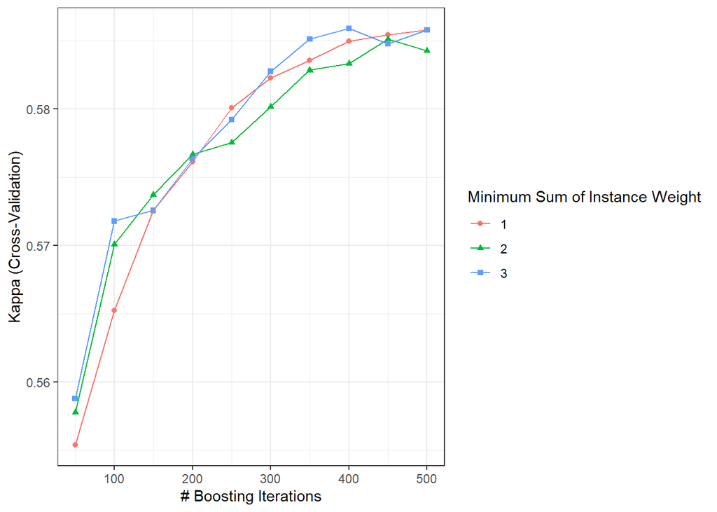

```r
ggplot(xgbDARTtuningmodel3classedseed4)+ theme_bw()
```

Gamma controls regularization (prevents overfitting). Gamma is minimum loss reduction required to make a further partition on a leaf node of the tree. The larger gamma is, the more conservative the algorithm will be.The main consequence of using a gamma different from 0 is to stop the algorithm from growing useless trees that barely reduce the in-sample error and are likely to result in over-fitting

```r
set.seed(42)

XGBoostgrid5 <- expand.grid(
  nrounds = seq(from = 50, to = 500, by = 50),
  eta = xgbDARTtuningmodel3classedseed$bestTune$eta,
  max_depth = xgbDARTtuningmodel3classedseed2$bestTune$max_depth,
  gamma = c(0, 0.1, 0.25, 0.5, 0.75, 1.0),
  colsample_bytree = xgbDARTtuningmodel3classedseed3$bestTune$colsample_bytree,
  min_child_weight = xgbDARTtuningmodel3classedseed4$bestTune$min_child_weight,
  rate_drop = xgbDARTtuningmodel3classedseed2$bestTune$rate_drop,
  skip_drop = xgbDARTtuningmodel3classedseed2$bestTune$skip_drop,
  subsample = xgbDARTtuningmodel3classedseed3$bestTune$subsample)

xgbDARTtuningmodel3classedseed5 <- caret::train(ternaryMoisture~., data = ternarytrainingData, trControl = tune_control, tuneGrid = XGBoostgrid5, method = "xgbDART",verbose = TRUE, metric="Kappa")
xgbDARTtuningmodel3classedseed5$bestTune
```

```
##   nrounds max_depth   eta gamma subsample colsample_bytree rate_drop skip_drop
## 9     450         4 0.025     0      0.75             0.75         0         0
##   min_child_weight
## 9                3
```

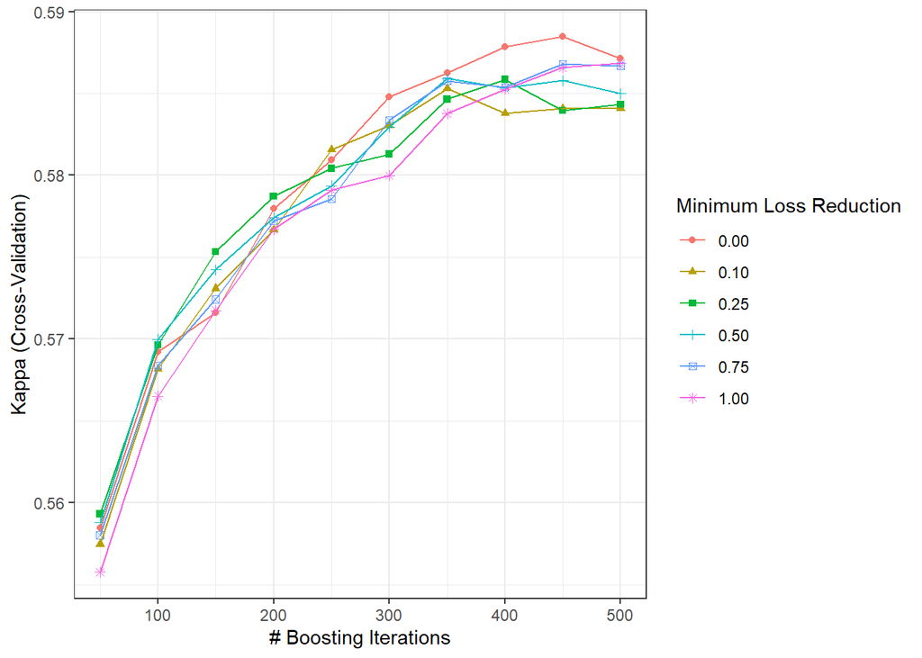

```r
ggplot(xgbDARTtuningmodel3classedseed5) + theme_bw()
```

We can now use the model with the optimal hyperpaamters and test it on the test data.

Test model on the hold out testing data. Class 1 = Dry Class 2 = Mesic - Moist Class 3 = wet

```r
XGBOOSTPredictions <-predict(xgbDARTtuningmodel3classedseed5, ternarytestData,ntree_limit=nrounds)
cmXGBOOST <-confusionMatrix(XGBOOSTPredictions, ternarytestData$ternaryMoisture)
print(cmXGBOOST)
```

```
## Confusion Matrix and Statistics
##
##           Reference
## Prediction    1    2    3
##          1 2159  318   22
##          2  238  612  170
##          3    6  123  280
##
## Overall Statistics
##
##                Accuracy : 0.7767
##                  95% CI : (0.7634, 0.7897)
##     No Information Rate : 0.6118
##     P-Value [Acc > NIR] : < 2.2e-16
##
##                   Kappa : 0.5777
##
##  Mcnemar's Test P-Value : 3.309e-06
##
## Statistics by Class:
##
##                      Class: 1 Class: 2 Class: 3
## Sensitivity            0.8985   0.5812  0.59322
## Specificity            0.7770   0.8581  0.96267
## Pos Pred Value         0.8639   0.6000  0.68460
## Neg Pred Value         0.8293   0.8483  0.94544
## Prevalence             0.6118   0.2681  0.12016
## Detection Rate         0.5496   0.1558  0.07128
## Detection Prevalence   0.6362   0.2597  0.10412
## Balanced Accuracy      0.8378   0.7196  0.77795
```

```r
XGBoosttable<-cmXGBOOST$byClass
XGBoosttable
```

```
##          Sensitivity Specificity Pos Pred Value Neg Pred Value Precision
## Class: 1   0.8984603   0.7770492      0.8639456      0.8292512 0.8639456
## Class: 2   0.5811966   0.8580870      0.6000000      0.8483494 0.6000000
## Class: 3   0.5932203   0.9626736      0.6845966      0.9454390 0.6845966
##             Recall        F1 Prevalence Detection Rate Detection Prevalence
## Class: 1 0.8984603 0.8808650  0.6117617      0.5496436            0.6362016
## Class: 2 0.5811966 0.5904486  0.2680754      0.1558045            0.2596741
## Class: 3 0.5932203 0.6356413  0.1201629      0.0712831            0.1041242
##          Balanced Accuracy
## Class: 1         0.8377547
## Class: 2         0.7196418
## Class: 3         0.7779470
```

This plot show how important each variable is. Depth to water, topographic wetness index from a 10m dem and mapped wetlands from the swedish property map were the most important variables. If an unexpected variable is very important it might indicate bias in the data.

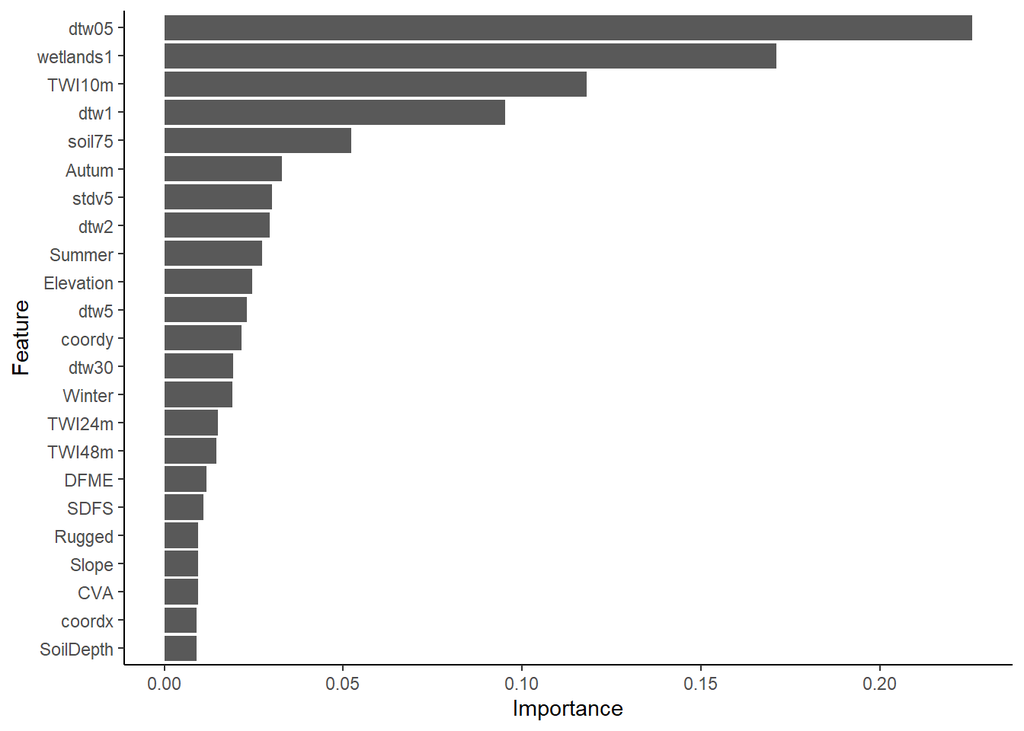

```r
ImportantVariables<-varImp(xgbDARTtuningmodel3classedseed5, scale = FALSE)
importanceplot<-ggplot(ImportantVariables, top = 23) + theme_bw() + theme(panel.border = element_blank(), panel.grid.major = element_blank(), panel.grid.minor = element_blank(), axis.line = element_line(colour = "black"))
importanceplot
```

```r
ggsave(importanceplot, file = "x:/XGBoostArticle/importanceplot3classes.png", dpi = 600)
```

When we put the model into production we will use all data to train the model without resampling. Both the training data and the testing data.

```r
set.seed(42)

Final_control <- caret::trainControl(method = "none", verboseIter = FALSE)
Final_grid <- expand.grid(
  nrounds = 450,
  eta = 0.025,
  max_depth = 4,
  gamma = 0,
  colsample_bytree = 0.75,
  min_child_weight = 3,
  rate_drop = 0,
  skip_drop = 0,
  subsample = 0.75
)

PredictModel <- caret::train(ternaryMoisture~., data = ternarydataset, trControl = Final_control, tuneGrid = Final_grid, method = "xgbDART",verbose = TRUE, metric="Kappa")
```

The trained model can be saved and used later

```r
saveRDS(PredictModel, "X:/MLWAM_Production/SavedModel/MLWAM3Classes.rds")
#To load the model later simply use:
#PredictModel <- readRDS("X:/MLWAM_Production/SavedModel/MLWAM3Classes.rds")
```

Save predictions to table for further processing

```r
FinalPredictions <-predict(PredictModel, ternarydataset, ntree_limit=nrounds)
CompleteTable<-cbind(ternarydataset,FinalPredictions)
write.table(CompleteTable,"x:/XGBoostArticle/Table3classes.txt", append = FALSE, sep = " ", dec = ".",
            row.names = TRUE, col.names = TRUE)
```

Finally we can put the model into production and predict soil moisture. All input features are stacked into multibandrasters where each band is one feature. This script will use parallel processing and predict one composite raster on each processor thread.